# A1_Tessmann_Meag

Meag Tessmann

1/13/2020

# Code Chunk 1: Install Libraries, import data, and inspect the code

A. Load packages using library() and import data using read.csv(). Load factors as character strings first. Take a look at the overall structure of the input data. B. Transform all string variables that include categorical values to factor variables. After this transformation, show the overall structure and summary of the input data.

```r
#
library(rmarkdown)
library(psych)
library(caret) # model creation
library(C50) # decision trees
library(rminer)
library(skimr) # data overview
library(tidyverse) # data manipulation
```

```r
library(scales) #for plotting moneyies
# read in data + preview structure
churn <- read.csv('churn_balanced.csv', stringsAsFactors=FALSE)
skim(churn)
```

```
## Skim summary statistics
##  n obs: 20000
##  n variables: 12
##
## ── Variable type:character ──────────────────────────────────────────────────────
##                    variable missing complete     n min max empty n_unique
##                     COLLEGE       0    20000 20000   3   4     0        2
##  CONSIDERING_CHANGE_OF_PLAN       0    20000 20000   2  24     0        5
##                       LEAVE       0    20000 20000   4   5     0        2
##       REPORTED_SATISFACTION       0    20000 20000   3  10     0        5
##        REPORTED_USAGE_LEVEL       0    20000 20000   3  11     0        5
##
## ── Variable type:integer ────────────────────────────────────────────────────────
##                     variable missing complete     n      mean        sd     p0
##        AVERAGE_CALL_DURATION       0    20000 20000      6         4.4       1
##                HANDSET_PRICE       0    20000 20000    389.62    213.82    130
##                        HOUSE       0    20000 20000 493155.26 252407.88 150002
##                       INCOME       0    20000 20000  80281.45  41680.59  20007
##                     LEFTOVER       0    20000 20000     23.9      26.82      0
##  OVER_15MINS_CALLS_PER_MONTH       0    20000 20000      8         8.93      0
##                      OVERAGE       0    20000 20000     85.98     85.99     -2
##        p25      p50       p75   p100     hist
##       2         5       10        15 ▇▃▅▁▁▂▂▂
##     219       326      533.25    899 ▇▆▆▂▂▂▂▂
##  263714.25 452259.5  7e+05     1e+06 ▇▆▅▃▃▃▃▃
##   42217     75366.5 115881.75 159983 ▇▇▅▅▅▃▃▅
##       0        14       41        89 ▇▃▂▁▁▁▁▁
##       1         4       15        29 ▇▃▁▁▁▁▁▁
##       0        59      179       335 ▇▆▁▁▃▂▁▁
```

```r
# change categorical levels to factors
churn <- churn %>%
  mutate(
    COLLEGE = factor(COLLEGE),
    CONSIDERING_CHANGE_OF_PLAN = factor(CONSIDERING_CHANGE_OF_PLAN),
    LEAVE = factor(LEAVE),
    REPORTED_SATISFACTION = factor(REPORTED_SATISFACTION),
    REPORTED_USAGE_LEVEL = factor(REPORTED_USAGE_LEVEL)
  )

skim(churn)
```

```
## Skim summary statistics
##  n obs: 20000
##  n variables: 12
##
## ── Variable type:factor ─────────────────────────────────────────────────────────
##                    variable missing complete     n n_unique
##                     COLLEGE       0    20000 20000        2
##  CONSIDERING_CHANGE_OF_PLAN       0    20000 20000        5
##                       LEAVE       0    20000 20000        2
##       REPORTED_SATISFACTION       0    20000 20000        5
##        REPORTED_USAGE_LEVEL       0    20000 20000        5
##                                  top_counts ordered
##                one: 10048, zer: 9952, NA: 0   FALSE
##   con: 7920, act: 4994, no: 4038, nev: 1995   FALSE
##                STA: 10148, LEA: 9852, NA: 0   FALSE
##  ver: 7909, ver: 5053, uns: 3991, avg: 2022   FALSE
##  lit: 7875, ver: 5109, ver: 4021, hig: 2000   FALSE
##
## ── Variable type:integer ────────────────────────────────────────────────────────
##                     variable missing complete     n      mean        sd     p0
##        AVERAGE_CALL_DURATION       0    20000 20000      6         4.4       1
##                HANDSET_PRICE       0    20000 20000    389.62    213.82    130
##                        HOUSE       0    20000 20000 493155.26 252407.88 150002
##                       INCOME       0    20000 20000  80281.45  41680.59  20007
##                     LEFTOVER       0    20000 20000     23.9      26.82      0
##  OVER_15MINS_CALLS_PER_MONTH       0    20000 20000      8         8.93      0
##                      OVERAGE       0    20000 20000     85.98     85.99     -2
##        p25      p50       p75   p100     hist
##       2         5       10        15 ▇▃▅▁▁▂▂▂
##     219       326      533.25    899 ▇▆▆▂▂▂▂▂
##  263714.25 452259.5  7e+05     1e+06 ▇▆▅▃▃▃▃▃
##   42217     75366.5 115881.75 159983 ▇▇▅▅▅▃▃▅
##       0        14       41        89 ▇▃▂▁▁▁▁▁
##       1         4       15        29 ▇▃▁▁▁▁▁▁
##       0        59      179       335 ▇▆▁▁▃▂▁▁
```

# Code Chunk 2: EDA-Numeric

INCOME,OVERAGE,andLEFTOVER. For each of these variables, A. Create a histogram and include a title of the histogram. B. Create a boxplot and include a title in the plot. C. Show deciles of the variable (i.e., quantiles using 0%, 10%, 20%, …, 90%, 100%).

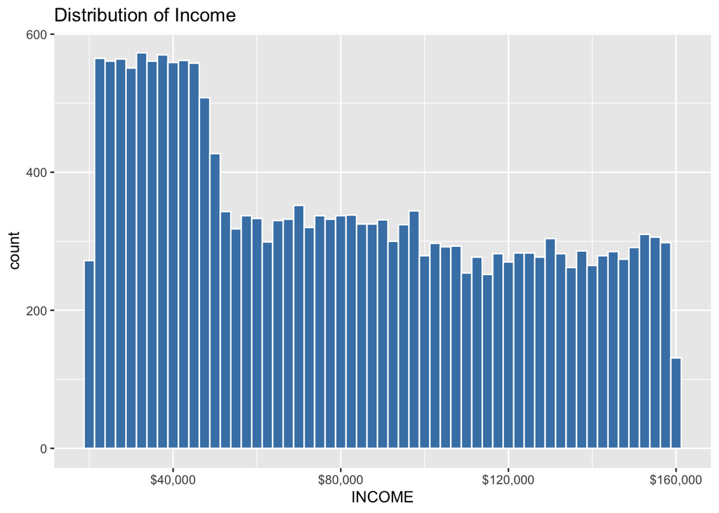

```r
# Explore Income
churn %>%
  ggplot(aes(INCOME)) +
  geom_histogram( binwidth = 2500, fill="steelblue", color="white") +
  scale_x_continuous(label=dollar) +
  ggtitle("Distribution of Income")
```

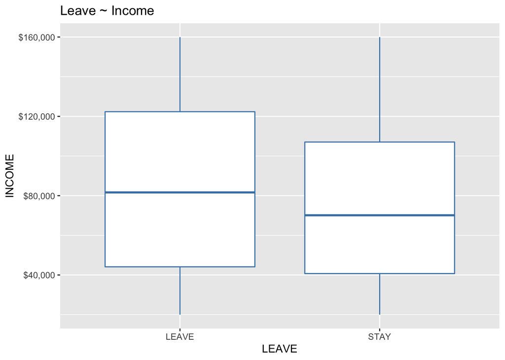

```r
churn %>%
  ggplot(aes(LEAVE, INCOME)) +
  geom_boxplot( color="steelblue") +
  scale_y_continuous(label=dollar) +
  ggtitle("Leave ~ Income")
```

```r
# Income Quantiles
quantile(churn$INCOME, seq(from = 0, to = 1, by = 0.10))
```

```
##       0%      10%      20%      30%      40%      50%      60%      70%
##  20007.0  28922.6  37873.6  46717.2  60182.8  75366.5  90369.6 106579.2
##      80%      90%     100%
## 124823.4 142797.9 159983.0
```

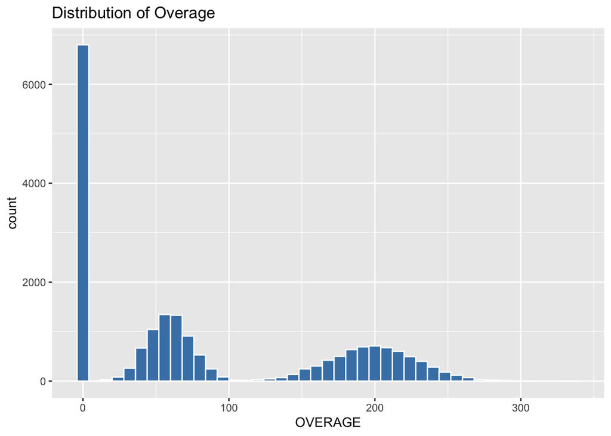

```r
# Explore Overage
churn %>%
  ggplot(aes(OVERAGE)) +
  geom_histogram( binwidth=8, fill="steelblue", color="white") +
  ggtitle("Distribution of Overage")
```

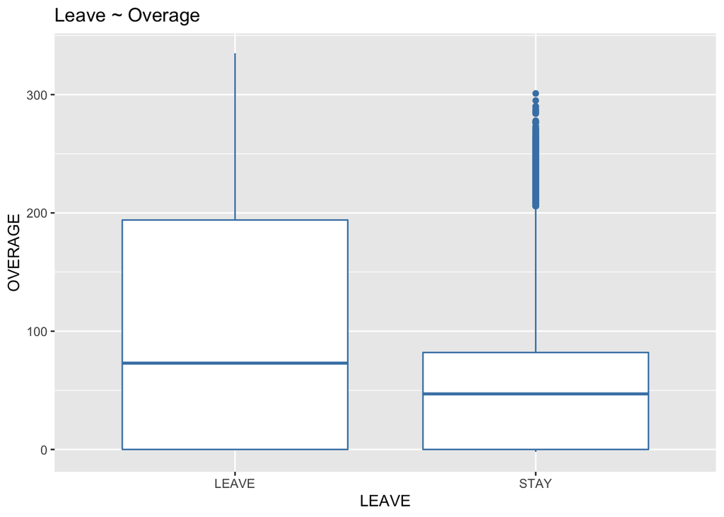

```r
churn %>%
  ggplot(aes(LEAVE, OVERAGE)) +
  geom_boxplot( color="steelblue") +
  ggtitle("Leave ~ Overage")
```

```r
# Overage Quantiles
quantile(churn$OVERAGE, seq(from = 0, to = 1, by = 0.10))
```

```
##   0%  10%  20%  30%  40%  50%  60%  70%  80%  90% 100%
##   -2    0    0    0   46   59   72  160  192  215  335
```

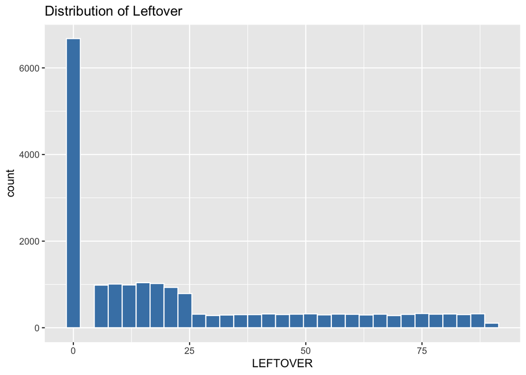

```r
# Explore Leftover
churn %>%
  ggplot(aes(LEFTOVER)) +
  geom_histogram(binwidth = 3, fill="steelblue", color="white") +
  ggtitle("Distribution of Leftover")
```

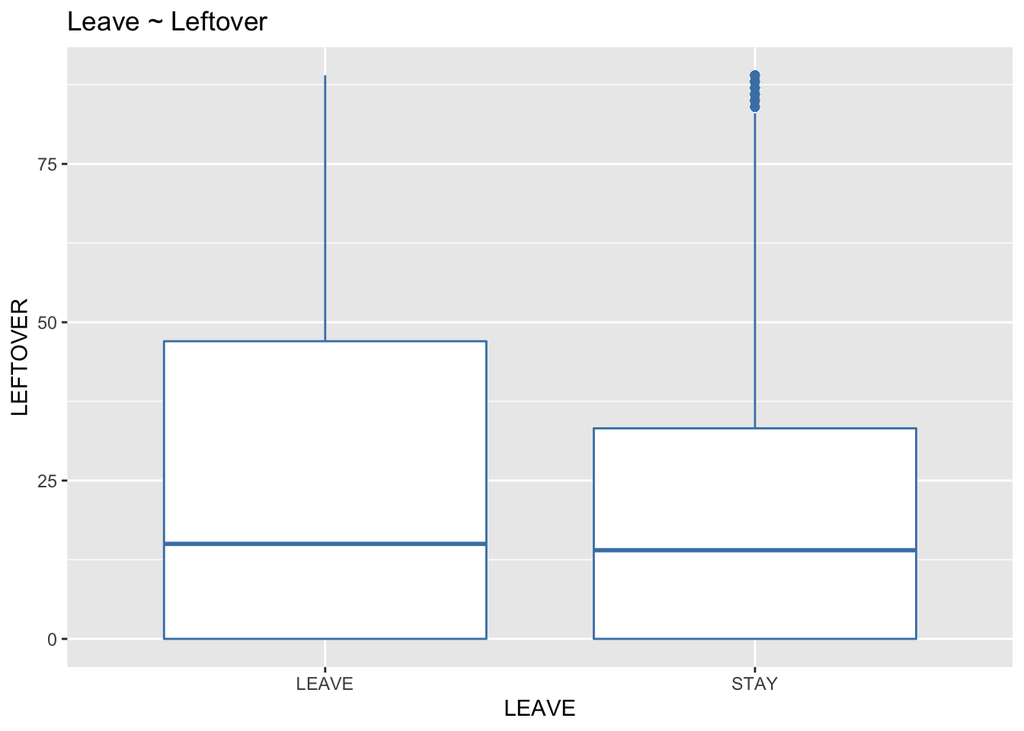

```r
churn %>%
  ggplot(aes(LEAVE, LEFTOVER)) +
  geom_boxplot( color="steelblue") +
  ggtitle("Leave ~ Leftover")
```

```r
# Leftover Quantiles
quantile(churn$LEFTOVER, seq(from = 0, to = 1, by = 0.10))
```

```
##   0%  10%  20%  30%  40%  50%  60%  70%  80%  90% 100%
##    0    0    0    0    9   14   20   31   51   70   89
```

# Code Chunk 3: EDA - Factors

A. For each of the factor variables in the dataset, and for each of this variable’s categorical values (e.g., “LEAVE” and “STAY” of LEAVE), show the count value and percentage value of instances that belong to that level. B. For each of the two factor variables LEAVE and REPORTED_SATISFACTION, show a bar plot of the number of instances (i.e. count) of each categorical value. The bars should be arranged in the descending order of instance count. Show a descriptive title in each plot.

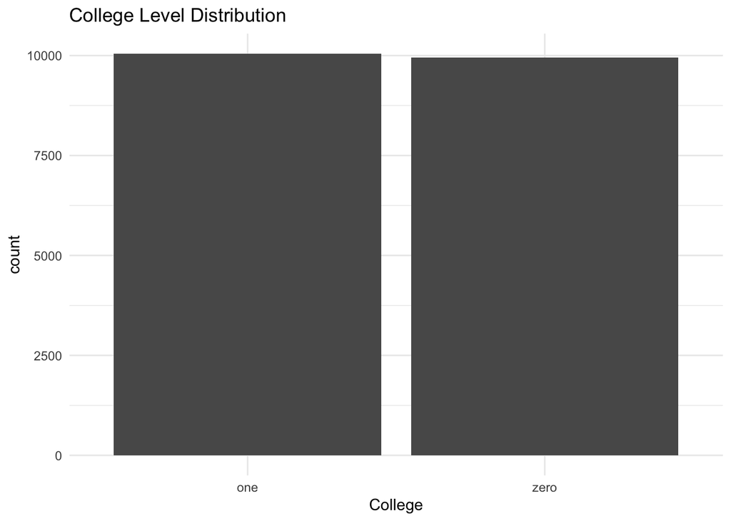

```r
# College dist
churn %>%
  ggplot(aes(COLLEGE)) +
  geom_bar(stat='count') +
  theme_minimal() +
  xlab("College") +
  ggtitle("College Level Distribution")
```

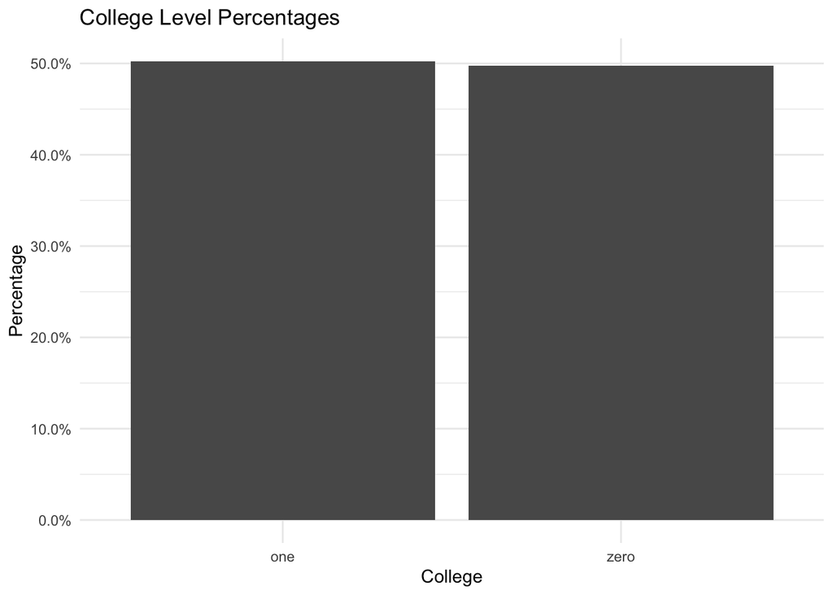

```r
# College as percentage
prop_college <- as.data.frame(prop.table(table(churn$COLLEGE)))
ggplot(prop_college, aes(Var1, Freq)) + geom_col() +
  theme_minimal() +
  xlab("College") +
  ylab("Percentage") +
  scale_y_continuous(labels=percent) +
  ggtitle("College Level Percentages")
```

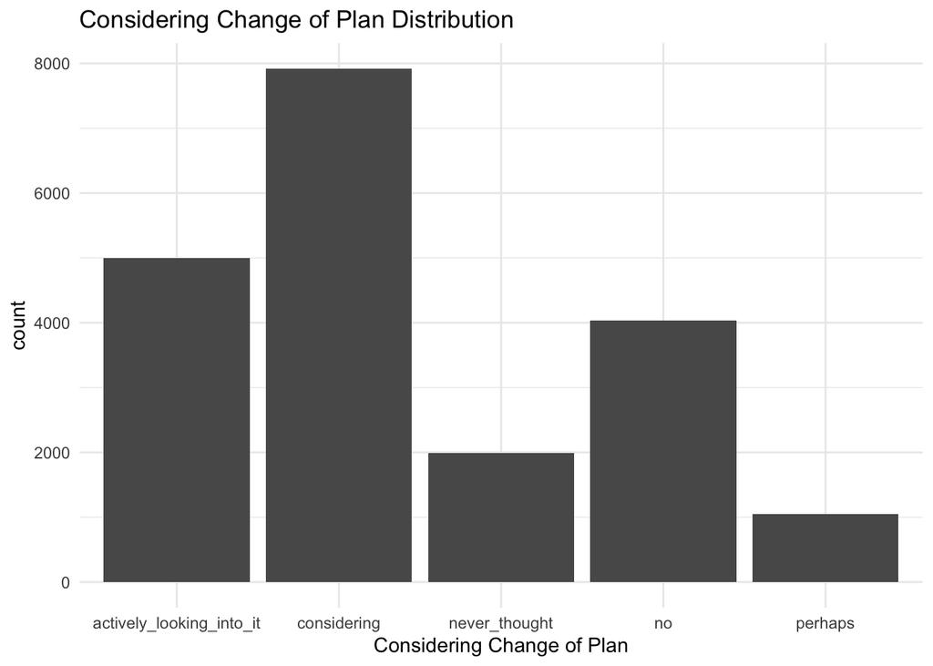

```r
# Considering plan change dist
churn %>%
  ggplot(aes(CONSIDERING_CHANGE_OF_PLAN)) +
  geom_bar(stat='count') +
  theme_minimal() +
  xlab("Considering Change of Plan") +
  ggtitle("Considering Change of Plan Distribution")
```

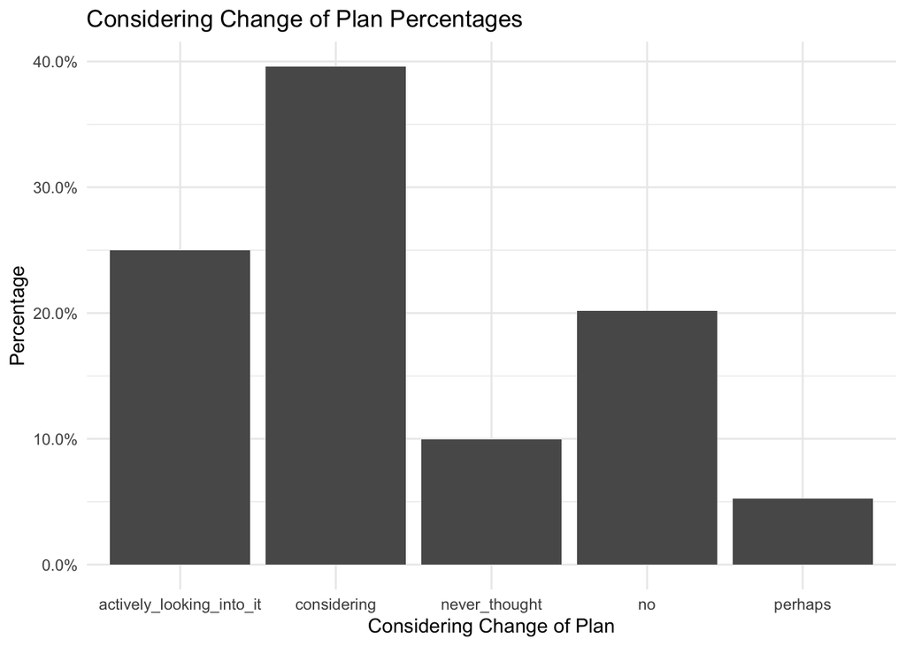

```r
# Considering plan change as percentage
prop_plan_change <- as.data.frame(prop.table(table(churn$CONSIDERING_CHANGE_OF_PLAN)))
ggplot(prop_plan_change, aes(Var1, Freq)) + geom_col() +
  theme_minimal() +
  xlab("Considering Change of Plan") +
  ylab("Percentage") +
  scale_y_continuous(labels=percent) +
  ggtitle("Considering Change of Plan Percentages")
```

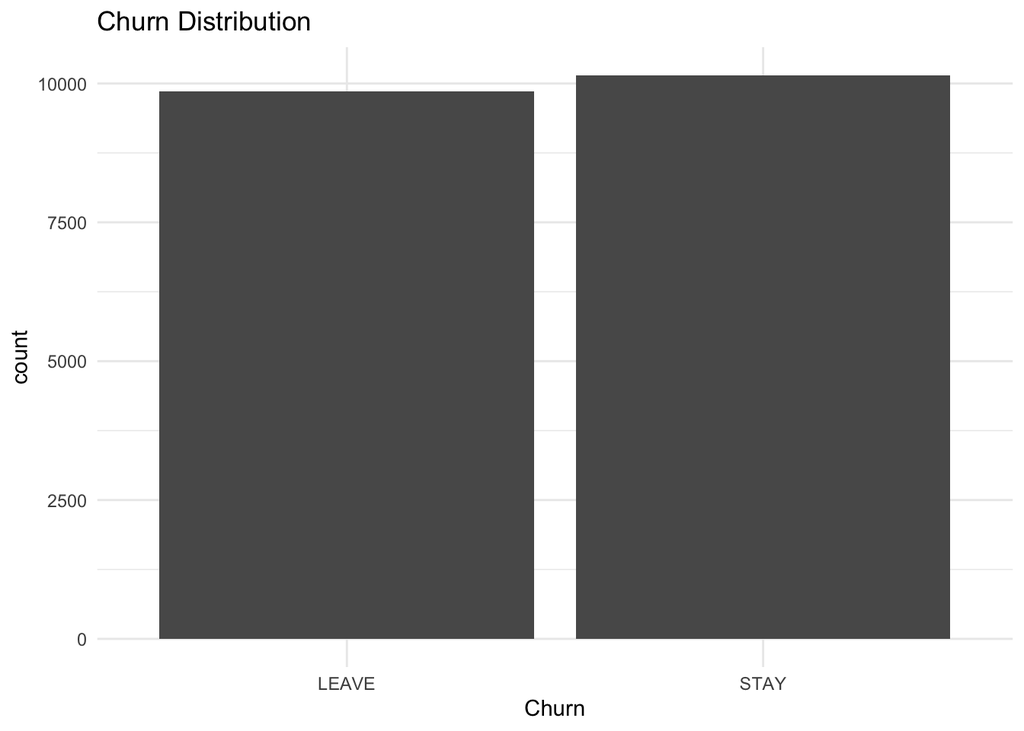

```r
# LEAVE dist
churn %>%
  ggplot(aes(LEAVE)) +
  geom_bar(stat='count') +
  theme_minimal() +
  xlab("Churn") +
  ggtitle("Churn Distribution")
```

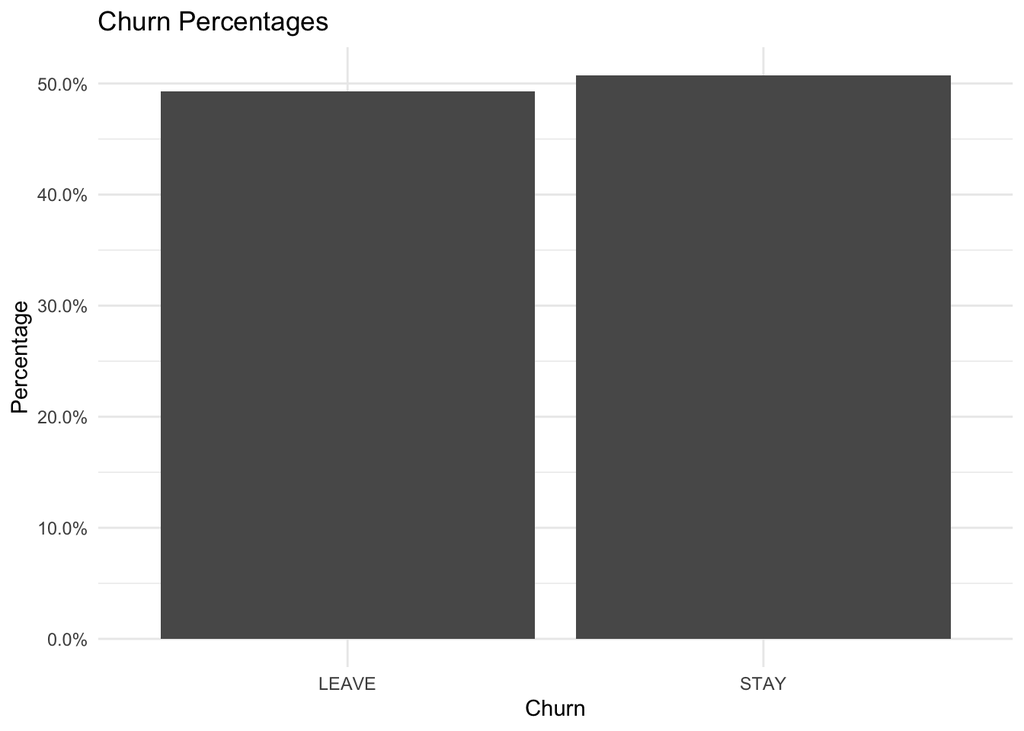

```r
# LEAVE as percentage
prop_leave <- as.data.frame(prop.table(table(churn$LEAVE)))
ggplot(prop_leave, aes(Var1, Freq)) + geom_col() +
  theme_minimal() +
  xlab("Churn") +
  ylab("Percentage") +
  scale_y_continuous(labels=percent) +
  ggtitle("Churn Percentages")
```

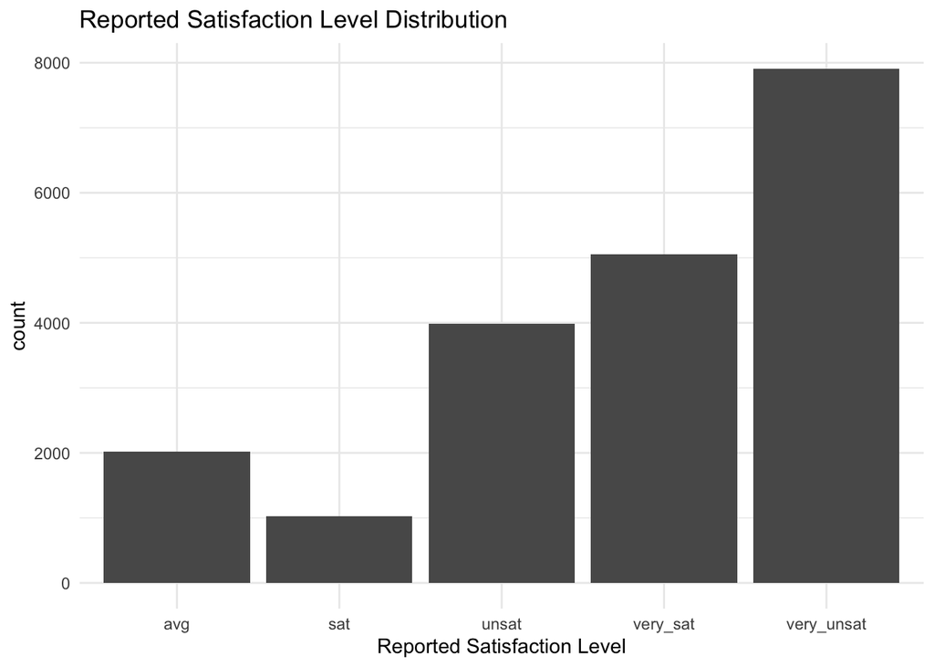

```r
# REPORTED_SATISFACTION dist
churn %>%
  ggplot(aes(REPORTED_SATISFACTION)) +
  geom_bar(stat='count') +
  theme_minimal() +
  xlab("Reported Satisfaction Level") +
  ggtitle("Reported Satisfaction Level Distribution")
```

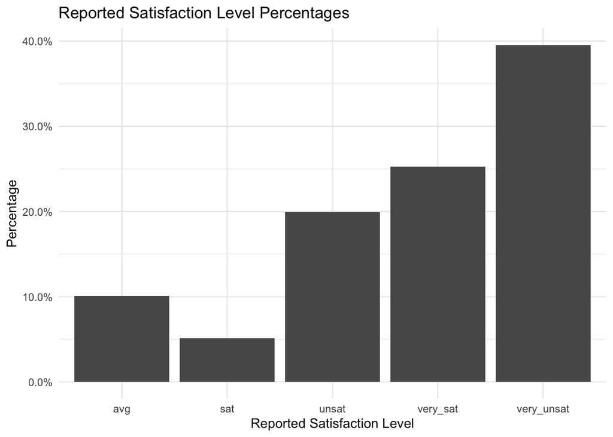

```r
# REPORTED_SATISFACTION as percentage
prop_satis <- as.data.frame(prop.table(table(churn$REPORTED_SATISFACTION)))
ggplot(prop_satis, aes(Var1, Freq)) + geom_col() +
  theme_minimal() +
  xlab("Reported Satisfaction Level") +
  ylab("Percentage") +
  scale_y_continuous(labels=percent) +
  ggtitle("Reported Satisfaction Level Percentages")
```

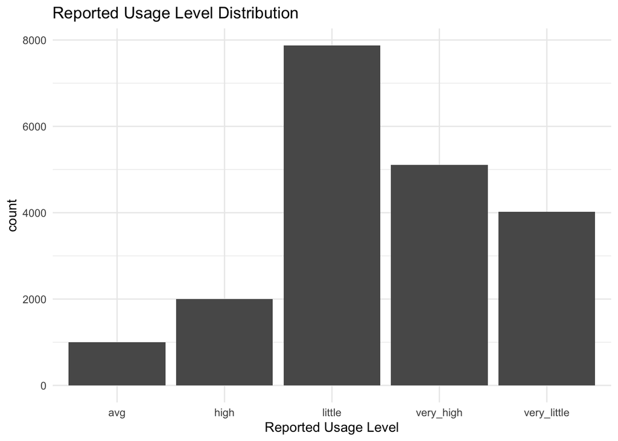

```r
# REPORTED_USAGE_LEVEL dist
churn %>%
  ggplot(aes(REPORTED_USAGE_LEVEL)) +
  geom_bar(stat='count') +
  theme_minimal() +
  xlab("Reported Usage Level") +
  ggtitle("Reported Usage Level Distribution")
```

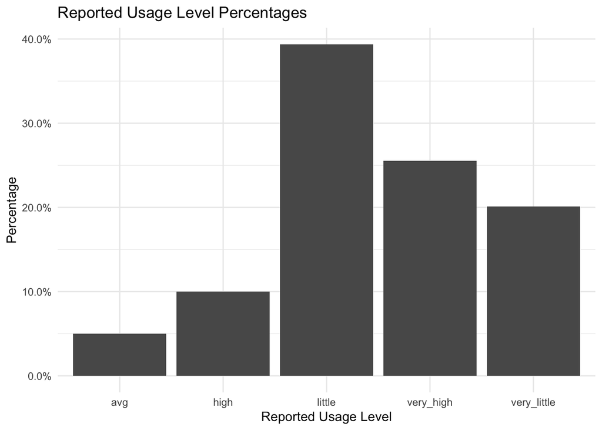

```r
# REPORTED_USAGE_LEVEL as percentage
prop_usage <- as.data.frame(prop.table(table(churn$REPORTED_USAGE_LEVEL)))
ggplot(prop_usage, aes(Var1, Freq)) + geom_col() +
  theme_minimal() +
  xlab("Reported Usage Level") +
  ylab("Percentage") +
  scale_y_continuous(labels=percent) +
  ggtitle("Reported Usage Level Percentages")
```

# Code Chunk 4: Correlations

A. Use cor display correlations among all of the numeric variables in the data set B. Use pairs.panels to display histograms/scatter plots and correlations based on all of the numeric variables and the target variable in the data set

```r
# Take all numeric variables
num_vars <- churn %>%
  select_if(is.numeric)

# get correlation matrix
cor(num_vars)
```

```
##                                    INCOME       OVERAGE     LEFTOVER
## INCOME                       1.0000000000  0.0004581106  0.006515440
## OVERAGE                      0.0004581106  1.0000000000 -0.003123310
## LEFTOVER                     0.0065154395 -0.0031233099  1.000000000
## HOUSE                       -0.0109639649  0.0024120975  0.006530155
## HANDSET_PRICE                0.7271996224  0.0003242996  0.004003553
## OVER_15MINS_CALLS_PER_MONTH  0.0021362688  0.7705567561 -0.010411348
## AVERAGE_CALL_DURATION       -0.0072194073  0.0006531099 -0.660285149
##                                    HOUSE HANDSET_PRICE
## INCOME                      -0.010963965  0.7271996224
## OVERAGE                      0.002412097  0.0003242996
## LEFTOVER                     0.006530155  0.0040035534
## HOUSE                        1.000000000 -0.0077563969
## HANDSET_PRICE               -0.007756397  1.0000000000
## OVER_15MINS_CALLS_PER_MONTH  0.007409535  0.0026803714
## AVERAGE_CALL_DURATION       -0.009359436 -0.0051904577
##                             OVER_15MINS_CALLS_PER_MONTH AVERAGE_CALL_DURATION
## INCOME                                      0.002136269         -0.0072194073
## OVERAGE                                     0.770556756          0.0006531099
## LEFTOVER                                   -0.010411348         -0.6602851486
## HOUSE                                       0.007409535         -0.0093594363
## HANDSET_PRICE                               0.002680371         -0.0051904577
## OVER_15MINS_CALLS_PER_MONTH                 1.000000000          0.0077685782
## AVERAGE_CALL_DURATION                       0.007768578          1.0000000000
```

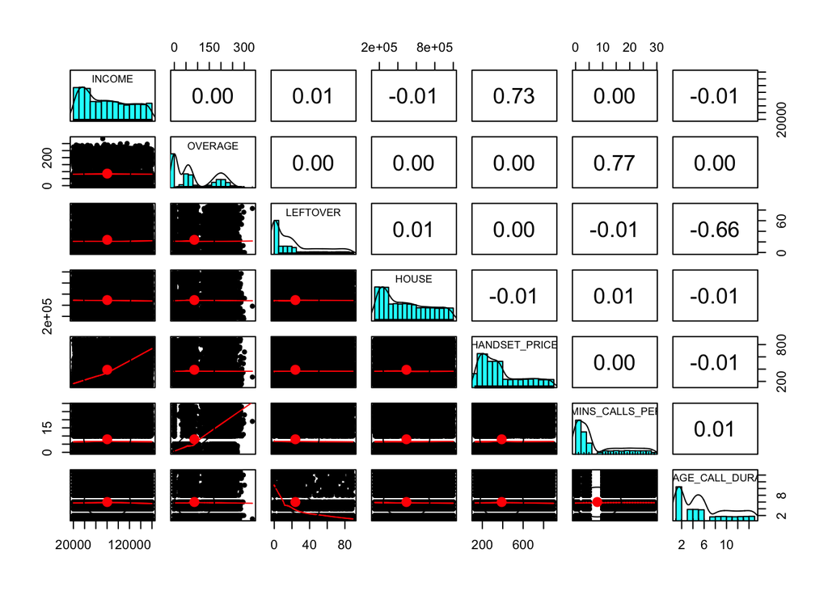

```r
# plot pair panels
pairs.panels(num_vars)
```